## 空間分析 期末考

#### 助教 杜承軒 2019.06.14

> ＊初步環境建置與讀取檔案

> ```r
> library(spdep);library(rgdal);library(GISTools);library(magrittr);library(spatstat)
> setwd("D:/1072SA/Fin")
> KH=readOGR(dsn =".", layer = "KH", encoding="utf8")
> TOWN=as.character(KH$TOWN)
> DG=readOGR(dsn =".", layer = "dengue", encoding="utf8")
> DG.den=DG$count/poly.areas(DG)
> TPE=readOGR(dsn =".", layer = "TPE", encoding="utf8")
> ```

> > Q1  
> > 請依據以下的鄰近定義，計算a.紅色網格及b.藍色網格分別的統計量，列出計算步驟及結果（列至小數後四位）。

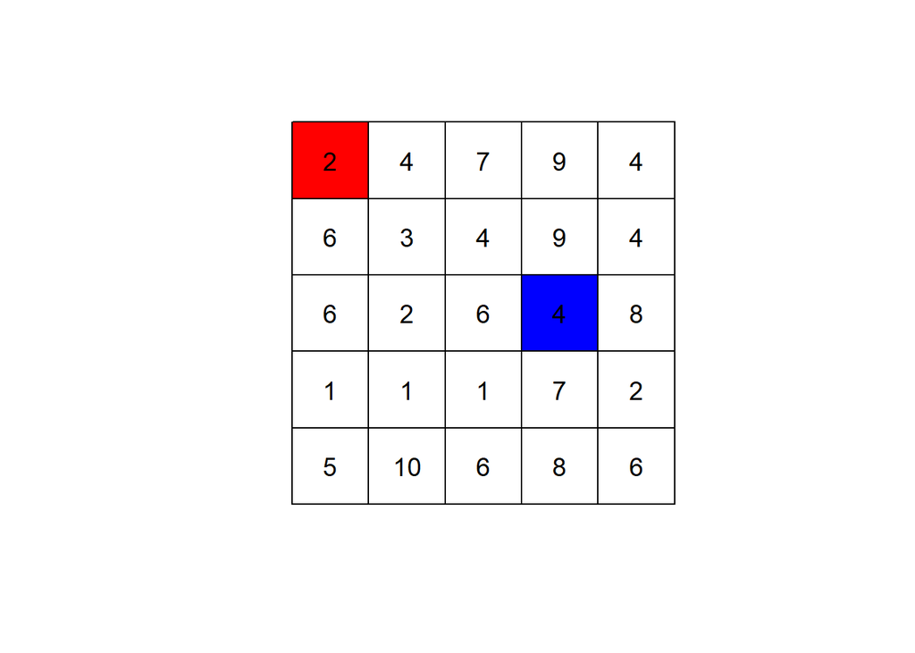

> (1)以QUEEN鄰近定義空間鄰近矩陣，**手動計算**兩個網格的Getis-Ord Local G統計量$G_i^*$。[5%]

> ```r
> .=c(2,4,7,9,4,6,3,4,9,4,6,2,6,4,8,1,1,1,7,2,5,10,6,8,6)
> Gia=sum(2,4,6,3)/sum(.)
> Gib=sum(4,9,4,6,4,8,1,7,2)/sum(.)
> ```

> (2)以ROOK鄰近並進行列標準化定義空間鄰近矩陣，**手動計算**兩個網格的Local Moran’s I統計量$I_i$。[10%]

> ```r
> .m=mean(.)
> .v=var(.)*24/25
> Iia=(2-.m)*((4-.m)+(6-.m))/.v/2
> Iib=(4-.m)*((9-.m)+(6-.m)+(8-.m)+(7-.m))/.v/4
> ```

> (3)透過R建立網格資料，使用相同定義計算上一小題的Local Moran’s I統計量$I_i$，並驗證兩者結果是否相同。[10%]

> ```r
> grd=GridTopology(c(0,0),c(1,1),c(5,5))
> grd=as.SpatialPolygons.GridTopology(grd)
> grd=SpatialPolygonsDataFrame(grd,data=data.frame(.),match.ID = F)
>
> grd.nb=poly2nb(grd,queen=F)
> grd.nb.w=nb2listw(grd.nb)
> grd.LISA=localmoran(grd$.,grd.nb.w)
>
> cat(sprintf("(1) Gi* a:% 5.4f , b:% 5.4f \n(2) Ii  a:% 5.4f , b:% 5.4f\n(3) Ii  a:% 5.4f , b:% 5.4f",Gia,Gib,Iia,Iib,grd.LISA[1,1],grd.LISA[14,1]))
> ```

> ```
> ## (1) Gi* a: 0.1200 , b: 0.3600
> ## (2) Ii  a:-0.0000 , b:-0.3634
> ## (3) Ii  a:-0.0000 , b:-0.3634
> ```

> > Q2  
> > 圖資KH.shp為高雄市35個行政區(不含3個原住民區)，其中欄位TOWN及TOWN_ID代表行政區名稱及編號。原本資料內有2018年市長選舉的藍綠比例值數值，透過localmoran函數來檢定哪些行政區的**局部空間自相關呈現正相關(顯著水準= 0.05)**，但現有的圖資只儲存了計算後原始的Local Moran’s I統計量$I_i$和其期望值$E(I_i)$、變異數$Var(I_i)$。

> (1)計算p-value，並列出**局部空間自相關呈現正相關**(α= 0.05)的行政區名稱。[5%]

> ```r
> zi=(KH$Ii-KH$E_Ii)/sqrt(KH$Var_Ii)
> pi=pnorm(zi,lower.tail = F)
> TOWN[pi<0.05]
> ```

> ```
> ## [1] "左營區" "美濃區" "甲仙區" "杉林區"
> ```

> (2)對所有行政區透過**手動計算**方式來進行FDR校正，**由小到大依序**列出校正後**p-value前三低**的行政區名稱。[10%]

> ```r
> p.fdr=pi*length(pi)/rank(pi)
> p.fdr[p.fdr>1]=1
> TOWN[order(p.fdr)[1:3]]
> ```

> ```
> ## [1] "杉林區" "甲仙區" "左營區"
> ```

> (3)透過**p.adjustSP函數**，考慮QUEEN的鄰近關係來校正FDR，並列出**局部空間自相關呈現正相關**(α= 0.05)的行政區名稱。[10%]

> ```r
> KH.nb=poly2nb(KH)
> p.fdr.sp=p.adjustSP(pi,KH.nb,method='fdr')
> TOWN[p.fdr.sp<0.05]
> ```

> ```
> ## [1] "左營區" "甲仙區" "杉林區"
> ```

> (4)上述(2)、(3)小題都是在進行FDR校正，請以文字說明，兩者概念與實作的差異為何？並比較那一個方法得出的結果較保守。[5%]

> ```r
> cat('前者以所有多邊形個數計算，後者考慮鄰居的個數來進行校正。前者較保守。')
> ```

> ```
> ## 前者以所有多邊形個數計算，後者考慮鄰居的個數來進行校正。前者較保守。
> ```

> > Q3  
> > 圖資dengue.shp為某年南高屏三縣市登革熱爆發的病例，其中欄位count為病例數。請以各鄉鎮病例密度（即每單位面積有多少病例）作為參考數值，以距離作為鄰近基準，來量測空間自相關。

> (1)評估各鄉鎮中心之間的距離，決定**鄰近距離d**，並說明選擇的原因。[5%]

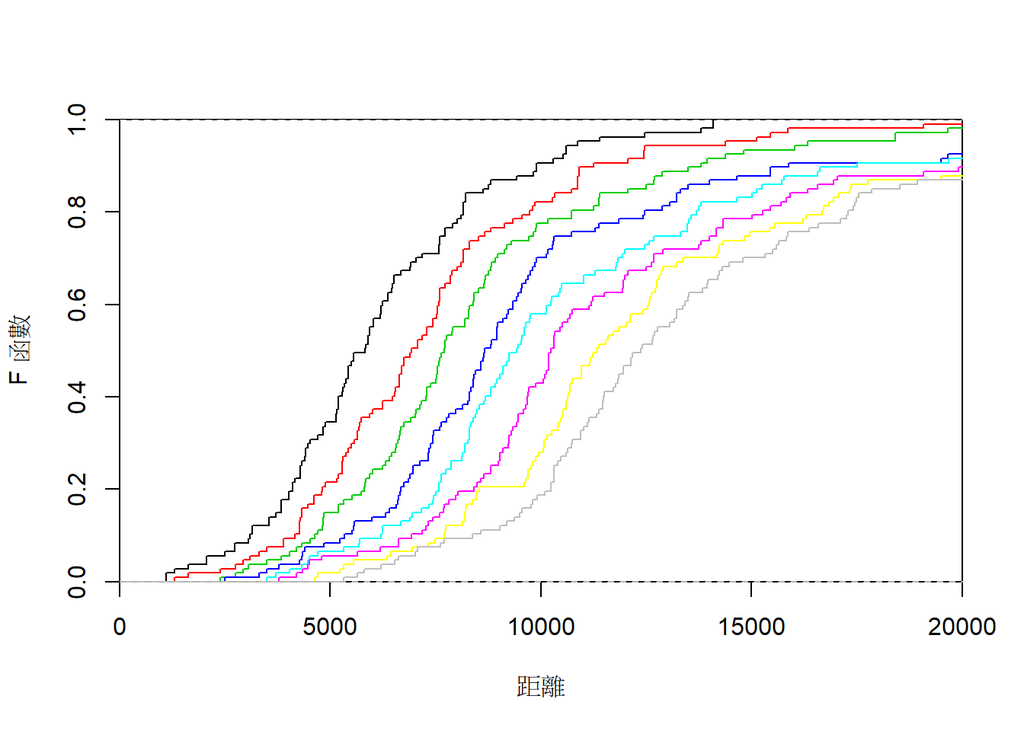

> ```r
> coord=coordinates(DG)
> x=coord[,1];y=coord[,2]
> cen=ppp(x,y,range(x),range(y))
> plot(c(0,20000),c(0,1),'n',xlab='距離',ylab='F 函數',xaxs = "i", yaxs ="i")
> for(i in 1:8) lines(ecdf(nndist(cen,k=i)),col=i,cex=0,verticals=T)
> ```

> ```r
> d=10000
> ```

> (2)以上述(1)的距離，以一階鄰近(距離0~d)為定義，繪製出LISA地圖(以顯著水準=0.1，呈現出HH、LL、HL、LH)。[5%]

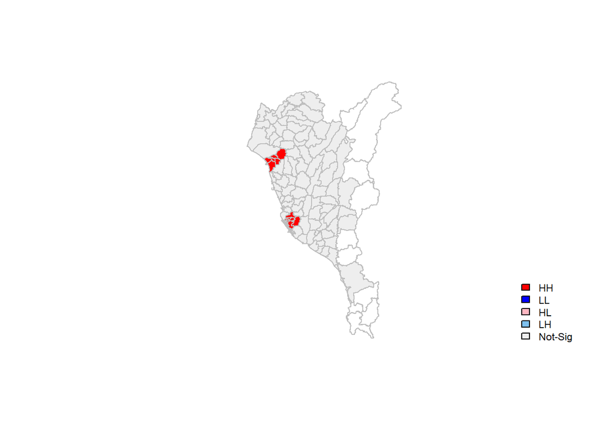

> ```r
> LISA=function(diff,lisa,p){
>  z=lisa[,4]
>  quad=c()
>  quad[diff>0 & z>0]=1;quad[diff<0 & z>0]=2;quad[diff>0 & z<0]=3;quad[diff<0 & z<0]=4;quad[lisa[, 5]>p]=5
>  return(quad)
> }
> LISA.legend=function(){legend("bottomright",legend=c("HH","LL","HL","LH","Not-Sig"), fill=colors,bty="n",cex=0.7,y.intersp=1,x.intersp=1)}
> colors=c("red", "blue", "lightpink", "skyblue2","#EEEEEE")
>
> TW.d=dnearneigh(coord,d1=0, d2=d)
> TW.dw=nb2listw(TW.d,zero.policy=T)
> DG.d1=localmoran(DG.den,TW.dw,zero.policy=T,alternative="two.sided")
> quad=LISA(DG.den-mean(DG.den),DG.d1,0.1)
> plot(DG, border="grey", col=colors[quad])
> LISA.legend()
> ```

> (3)以**第二階鄰近**(距離d~2d)為定義，繪製出LISA地圖(以顯著水準=0.1，呈現出HH、LL、HL、LH)。[10%]

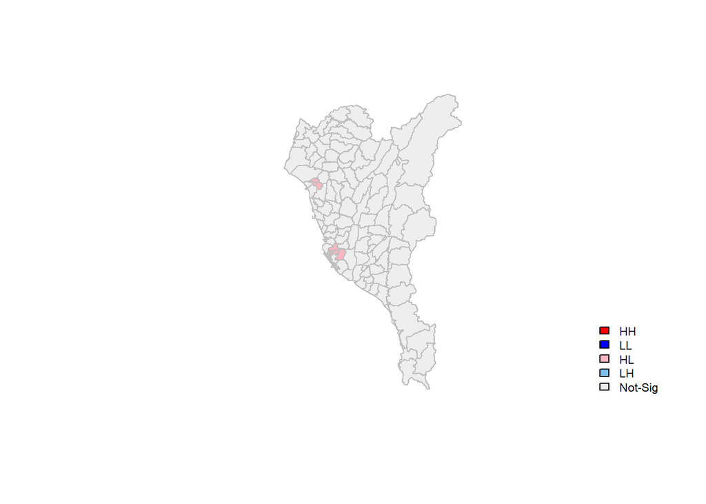

> ```r
> TW.d2=dnearneigh(coord,d1=d, d2=d*2)
> TW.dw2=nb2listw(TW.d2,zero.policy=T)
> DG.d2=localmoran(DG.den,TW.dw2,zero.policy=T,alternative="two.sided")
> quad=LISA(DG.den-mean(DG.den),DG.d2,0.1)
> plot(DG, border="grey", col=colors[quad])
> LISA.legend()
> ```

> (4)說明(2)、(3)地圖代表的地理意涵。[5%]

> ```r
> cat('第一階鄰近捕捉熱區，第二階鄰近捕捉登革熱傳播隨距離遞減的效應')
> ```

> ```
> ## 第一階鄰近捕捉熱區，第二階鄰近捕捉登革熱傳播隨距離遞減的效應
> ```

> > Q4  
> > 圖資TPE.shp為台北市次分區，其中欄位DEN代表個次分區中的人口密度。以QUEEN鄰近並進行列標準化定義鄰近關係，來計算空間自相關的數值。過去課程實習在檢定的方法，都是以moran.mc或localmoran函數中已經執行的結果，如下圖。

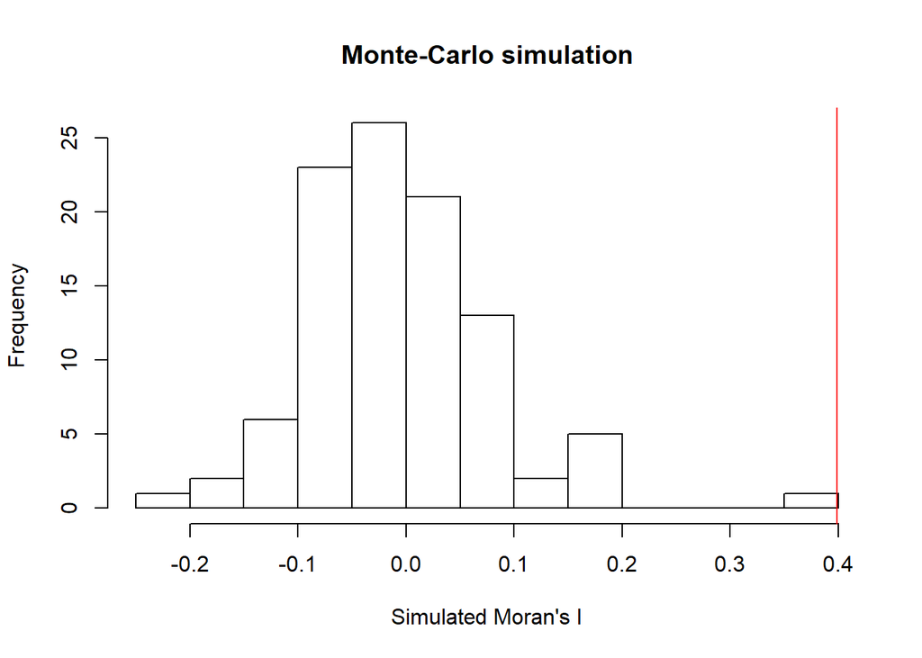

> > 希望能用手動模擬的方式，也能得到類似的結果，因此，請透過排列檢定(permutation test)，模擬99次的隨機情形，比較觀察值與隨機值。

> (1)繪製出Global Moran’s I的直方圖。[10%]  
> (2) 透過與隨機值的排序比較，計算各個區局部空間自相關呈現正相關的p-value。並以data.frame的方式，呈現**行政區名、localmoran函數算出來的p-value、模擬計算p-value**，如下圖。[10%]  
> (注意：模擬次數加上觀察值為100次，故模擬計算p-value一定是二位以下的小數；而下圖localmoran函數算出來的p-value有經過四捨五入)

> ```
> ##          TPE p_org p_sim
> ## 0   三民地區  0.60  0.64
> ## 1   東社地區  0.63  0.69
> ## 2   中崙地區  0.04  0.02
> ## 3   本鎮地區  0.04  0.01
> ## 4 三張犁地區  0.08  0.05
> ```

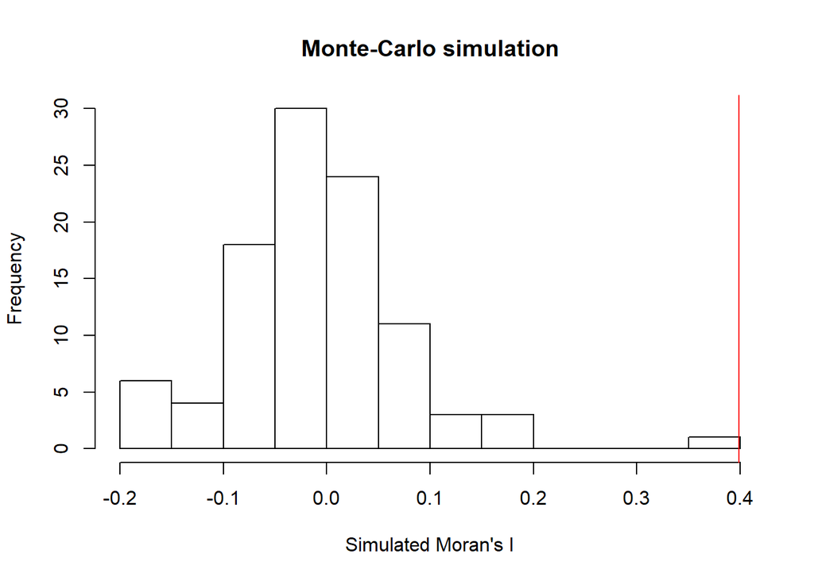

> ```r
> TW.c=poly2nb(TPE)
> TW.cw=nb2listw(TW.c)
> den=TPE$DEN
> mc=moran.mc(den,listw=TW.cw,nsim=99)
> MoranI=mc$statistic
> LISA=localmoran(den,listw=TW.cw)
> Ii=LISA[,1]
> for(i in 1:99) {
>  s=sample(den)
>  MoranI=c(MoranI,moran.test(s,listw=TW.cw)$estimate[1])
>  Ii=cbind(Ii,localmoran(s,listw=TW.cw)[,1])
> }
>
> hist(MoranI, freq=TRUE, breaks=10, xlab="Simulated Moran's I",main="Monte-Carlo simulation")
> abline(v=MoranI[1], col="red")
> ```

> ```r
> p.sim=apply(Ii,1,function(x) as.numeric((101-rank(x))[1])/100)
> data.frame(TPE=TPE$SEC_NAME,p_org=round(LISA[,5],2),p.sim)
> ```

> ```
> ##           TPE p_org p.sim
> ## 0    三民地區  0.60  0.68
> ## 1    東社地區  0.63  0.77
> ## 2    中崙地區  0.04  0.09
> ## 3    本鎮地區  0.04  0.07
> ## 4  三張犁地區  0.08  0.07
> ## 5  五分埔地區  0.10  0.08
> ## 6    福德地區  0.47  0.42
> ## 7    吳興地區  0.26  0.30
> ## 8  六張犁地區  0.45  0.39
> ## 9    和平地區  0.20  0.12
> ## 10   學府地區  0.63  0.69
> ## 11   瑞安地區  0.00  0.01
> ## 12   新生地區  0.19  0.11
> ## 13   敦南地區  0.00  0.01
> ```
>
> [output cut: 54 more lines]